# Multivariate: using R to replace SPSS

This notebook was created as part of my journey in a master's class where the instructor used SPSS for multivariate analysis. Since I prefer not to use SPSS, I explored ways to perform the same analyses using R. My goal is to replicate all SPSS commands with R, and this notebook documents that process.

This notebook will cover how to open and read SPSS files, conduct summaries for univariate and bivariate variables, and then delve into topics such as factor analysis, principal component analysis (PCA), discriminant analysis, regression, and clustering.

## General setup

```r
# import libs
library(haven)
library(knitr)
library(kableExtra)
library(sjPlot)
library(tidyverse)
library(sjlabelled)
library(janitor) # for frequency summary
library(dplyr)
library(tables)
library(pivottabler)
library(ggplot2)
library(RColorBrewer)
library(vcdExtra)
library(stargazer)
library(DescTools)
library(labelled)
library(psych)
```

```r
# digit
options(digits = 3)

# ggplot
theme_set(theme_classic())
update_geom_defaults("bar", list(fill = 'steelblue'))
theme_update(
    text = element_text(size = 16) # Adjust the size as needed
)

# Set default theme and color palette
options(
    ggplot2.continuous.colour = function() scale_color_viridis_c(),
    ggplot2.continuous.fill = function() scale_fill_viridis_c(),
    ggplot2.discrete.colour = function() scale_color_brewer(palette = "Paired"),
    ggplot2.discrete.fill = function() scale_fill_brewer(palette = "Paired"),
    kable.format = "pandoc",
    par.bg = "white"
)
```

### function

```r
# function to get label of a variable or multiple variables
u_get_label <- function(data, var){
  if(length(var) == 1){
    return(attr(data[[var]], 'label'))
  } else {
    return(sapply(var, function(x) attr(data[[x]], 'label')))
  }
}
# show and format table
u_show_table <- function(dat, font_size = 15) {
  dat %>%
    kbl(table.attr = "style='width:auto; display:inline-block;'") %>%
    kable_styling(bootstrap_options = c("striped", "hover", "condensed", "responsive"),
                  font_size = font_size, full_width = FALSE)
}
```

## Import and process data

### import data

```r
# Load the dataset
dat_online <- read_sav("/Users/macbook/Library/CloudStorage/GoogleDrive-tranquangthanhcong@gmail.com/My Drive/study/ueh master/multivariate/data/MUASONLINE.sav")
head(dat_online,2)
```

A tibble: 2 x 26

| TT1 <dbl+lbl> | TT2 <dbl+lbl> | TT3 <dbl+lbl> | HH1 <dbl+lbl> | HH2 <dbl+lbl> | HH3 <dbl+lbl> | DV1 <dbl+lbl> | DV2 <dbl+lbl> | DV3 <dbl+lbl> | DV4 <dbl+lbl> | ... | Nghe <dbl+lbl> | Thu_nhap <dbl+lbl> | Hoc_van <dbl+lbl> | ctieums <dbl> | X1 <dbl> | X3 <dbl> | Y <dbl> | X2 <dbl> | CD_DH <dbl+lbl> | chitieuMH <dbl+lbl> |
| --- | --- | --- | --- | --- | --- | --- | --- | --- | --- | --- | --- | --- | --- | --- | --- | --- | --- | --- | --- | --- |
| 5 | 5 | 5 | 2 | 4 | 4 | 5 | 5 | 5 | 5 | ... | 1 | 3 | 2 | 0.5 | 5.0 | 3.33 | 4.92 | 5 | 1 | 1 |
| 4 | 4 | 4 | 4 | 4 | 4 | 3 | 3 | 3 | 4 | ... | 1 | 2 | 2 | 1.0 | 3.4 | 4.00 | 3.80 | 4 | 1 | 2 |

```r
# convert value to factors (readable)
dat_fact_online <- as_label(dat_online) %>% as_factor()
head(dat_fact_online,2)
```

A tibble: 2 x 26

| TT1 <fct> | TT2 <fct> | TT3 <fct> | HH1 <fct> | HH2 <fct> | HH3 <fct> | DV1 <fct> | DV2 <fct> | DV3 <fct> | DV4 <fct> | ... | Nghe <fct> | Thu_nhap <fct> | Hoc_van <fct> | ctieums <fct> | X1 <fct> | X3 <fct> | Y <fct> | X2 <fct> | CD_DH <fct> | chitieuMH <fct> |
| --- | --- | --- | --- | --- | --- | --- | --- | --- | --- | --- | --- | --- | --- | --- | --- | --- | --- | --- | --- | --- |
| Hoan toan dong y | Hoan toan dong y | Hoan toan dong y | Khong dong y | Dong y | Dong y | Hoan toan dong y | Hoan toan dong y | Hoan toan dong y | Hoan toan dong y | ... | Van phong | 15 tro len | cao dang-dai hoc | 0.5 | 5 | 3.33333333333333 | 4.91666666666667 | 5 | cao dang-dai hoc | 0.0-0.9 |
| Dong y | Dong y | Dong y | Dong y | Dong y | Dong y | Khong co y kien | Khong co y kien | Khong co y kien | Dong y | ... | Van phong | 10-14 | cao dang-dai hoc | 1 | 3.4 | 4 | 3.8 | 4 | cao dang-dai hoc | 1.0-1.9 |

```r
# view dictionary of variables
map(names(dat_online), ~ setNames(u_get_label(dat_online, .x), .x))
```

1. **TT1:** 'mua hang truc tuyen hoat dong 24h nen co the mua vao bat cu luc nao'

2. **TT2:** 'mua hang truc tuyen giup tiet kiem thoi gian'

3. **TT3:** 'cach thuc mua va thanh toan de dang'

4. **HH1:** 'san pham phu hop voi so tien ma toi tra'

5. **HH2:** 'san pham phong phu'

6. **HH3:** 'san pham dam bao chat luong nhu thong tin cung cap tren web'

7. **DV1:** 'nhan vien vui ve giai dap thac mac cua khach hang'

8. **DV2:** 'nhan vien luon ho tro khi khach hang can'

9. **DV3:** 'nhan vien luon giup do khach hang tan tinh'

10. **DV4:** 'khi mua sam online hang hoa duoc giao tan noi'

11. **DV5:** 'hang hoa duoc giao dung thoi han'

12. **HL1:** 'nhung nguoi xung quanh toi cung co nhung nhan xet tich cuc ve mua sam online'

13. **HL2:** 'nhung nhan xet tich cuc tren cac dien dan truc tuyen anh huong den quyet dinh mua hang cua toi'

14. **HL3:** 'toi se gioi thieu nguoi quen nen mua sam truc tuyen vi nhung tien ich cua no'

15. **GT1:** 'gioi tinh'

16. **Tuoi:** 'tuoi'

17. **Nghe:** 'nghe nghiep'

18. **Thu_nhap:** 'thu nhap'

19. **Hoc_van:** 'hoc van'

20. **ctieums:** 'chi tieu mua sam online hang thang'

21. **X1:** 'dv khach hang'

22. **X3:** 'hang hoa'

23. **Y:** 'hai long mua sam online'

24. **X2:** 'thuan tien'

25. **CD_DH:** 'cao dang-dai hoc'

26. **chitieuMH:** 'chi tieu ma hoa'

So, we load the data .sav successfully and ready for next step

## Summary

In this session we will use R to view summary about our data and do some descriptive analysis

### Group and report in table

**1 dimension**

```r
dat_fact_online %>% tabyl('TT1')  %>%
    adorn_pct_formatting()
```

A tabyl: 5 x 3

| TT1 <fct> | n <dbl> | percent <chr> |
| --- | --- | --- |
| Hoan toan khong dong y | 0 | 0.0% |
| Khong dong y | 0 | 0.0% |
| Khong co y kien | 5 | 1.9% |
| Dong y | 151 | 58.8% |
| Hoan toan dong y | 101 | 39.3% |

```r
dat_fact_online %>% tabyl('Hoc_van')  %>%
    adorn_pct_formatting()
```

A tabyl: 3 x 3

| Hoc_van <fct> | n <dbl> | percent <chr> |
| --- | --- | --- |
| pho thong trung hoc | 102 | 39.7% |
| cao dang-dai hoc | 139 | 54.1% |
| tren dai hoc | 16 | 6.2% |

**2 dimension**

```r
table(dat_fact_online$Thu_nhap, dat_fact_online$Hoc_van)
```

```
             pho thong trung hoc cao dang-dai hoc tren dai hoc
  duoi 10                     29               11            0
  10-14                       42               55           10
  15 tro len                  31               73            6
```

**3 dimension**

```r
ftable(dat_fact_online$GT1, dat_fact_online$Hoc_van, dat_fact_online$Thu_nhap)
```

```
                         duoi 10 10-14 15 tro len

Nam pho thong trung hoc        4     7          6
    cao dang-dai hoc           0     7         11
    tren dai hoc               0     2          1
Nu  pho thong trung hoc       25    35         25
    cao dang-dai hoc          11    48         62
    tren dai hoc               0     8          5
```

### Correlation

```r
head(dat_fact_online,2)
```

A tibble: 2 x 26

| TT1 <fct> | TT2 <fct> | TT3 <fct> | HH1 <fct> | HH2 <fct> | HH3 <fct> | DV1 <fct> | DV2 <fct> | DV3 <fct> | DV4 <fct> | ... | Nghe <fct> | Thu_nhap <fct> | Hoc_van <fct> | ctieums <fct> | X1 <fct> | X3 <fct> | Y <fct> | X2 <fct> | CD_DH <fct> | chitieuMH <fct> |
| --- | --- | --- | --- | --- | --- | --- | --- | --- | --- | --- | --- | --- | --- | --- | --- | --- | --- | --- | --- | --- |
| Hoan toan dong y | Hoan toan dong y | Hoan toan dong y | Khong dong y | Dong y | Dong y | Hoan toan dong y | Hoan toan dong y | Hoan toan dong y | Hoan toan dong y | ... | Van phong | 15 tro len | cao dang-dai hoc | 0.5 | 5 | 3.33333333333333 | 4.91666666666667 | 5 | cao dang-dai hoc | 0.0-0.9 |
| Dong y | Dong y | Dong y | Dong y | Dong y | Dong y | Khong co y kien | Khong co y kien | Khong co y kien | Dong y | ... | Van phong | 10-14 | cao dang-dai hoc | 1 | 3.4 | 4 | 3.8 | 4 | cao dang-dai hoc | 1.0-1.9 |

```r
dat_online %>% select(X1, X2, X3, Y) %>% cor() %>% kable(format = 'pandoc', digits = 2)
```

```
        X1     X2     X3      Y
---  -----  -----  -----  -----
X1    1.00   0.37   0.04   0.89
X2    0.37   1.00   0.03   0.63
X3    0.04   0.03   1.00   0.01
Y     0.89   0.63   0.01   1.00
```

### Plot

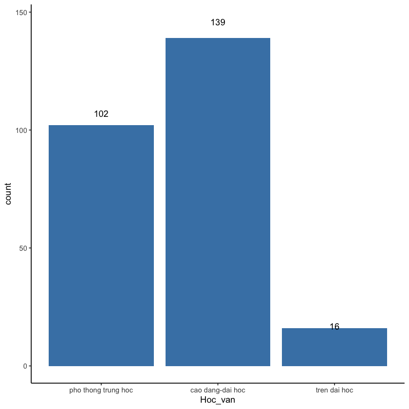

```r
# frequency bar chart
ggplot(dat_fact_online, aes(x = Hoc_van)) +
  geom_bar() +
  geom_text(aes(label = ..count..), stat = "count", position = position_stack(v=1.05)) +
  theme_classic() # Adjust global text size
```

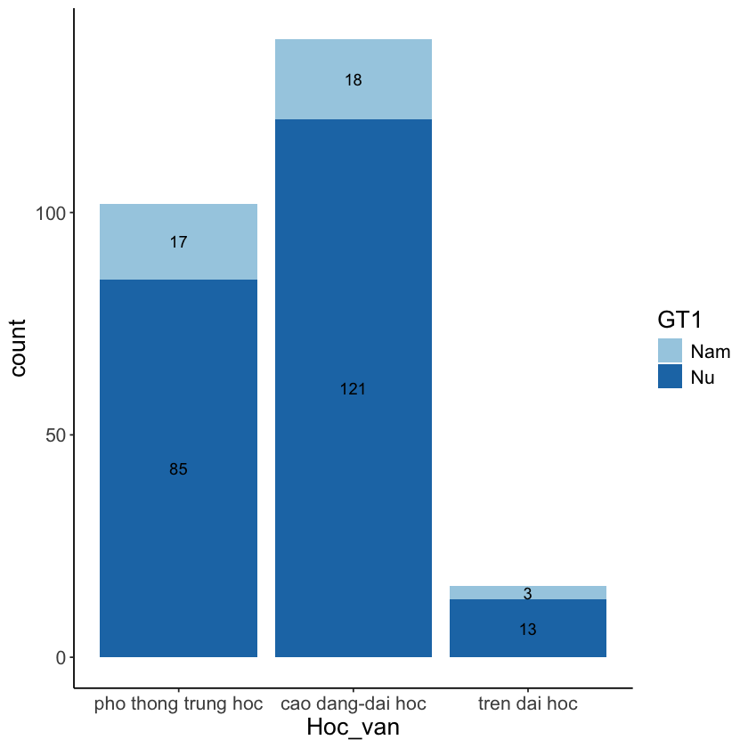

```r
# stacked bar chart
ggplot(dat_fact_online, aes(x = Hoc_van,fill=GT1)) +
  geom_bar() + geom_text(aes(label = ..count..), stat = "count", position = position_stack(vjust = 0.5))
```

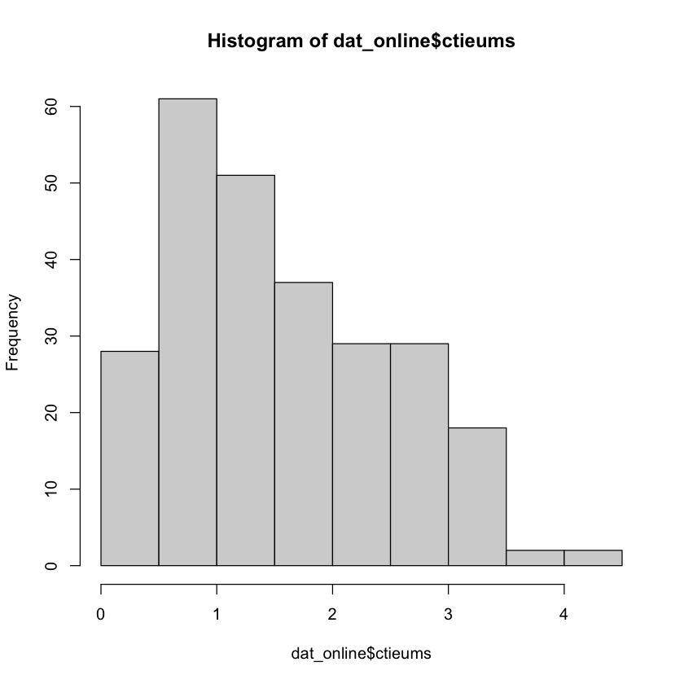

```r
# histogram
hist(dat_online$ctieums)
```

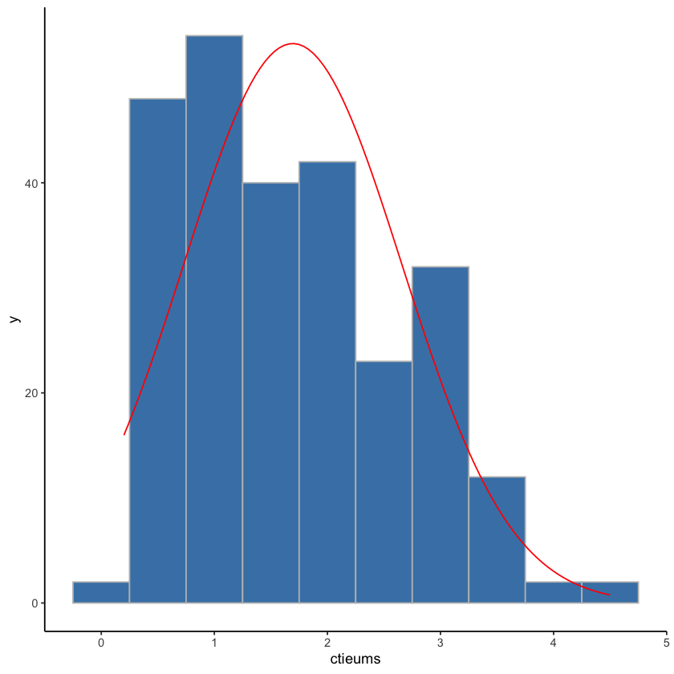

```r
# histogram by ggplot2
ggplot(dat_online, aes(x = ctieums)) +
  geom_histogram(binwidth = 0.5, color='gray') +
  stat_function(fun = function(x) dnorm(x, mean = mean(dat_online$ctieums), sd = sd(dat_online$ctieums)) * length(dat_online$ctieums) * 0.5, color = "red") +
  theme_classic()
```

```r
# digit
options(digits = 3)

# ggplot
theme_set(theme_classic())
update_geom_defaults("bar", list(fill = 'steelblue'))

# Set default theme and color palette
options(
    ggplot2.continuous.colour = function() scale_color_viridis_c(),
    ggplot2.continuous.fill = function() scale_fill_viridis_c(),
    ggplot2.discrete.colour = function() scale_color_brewer(palette = "Paired"),
    ggplot2.discrete.fill = function() scale_fill_brewer(palette = "Paired")
)

# Set default background color for plots
par(bg = "white")
```

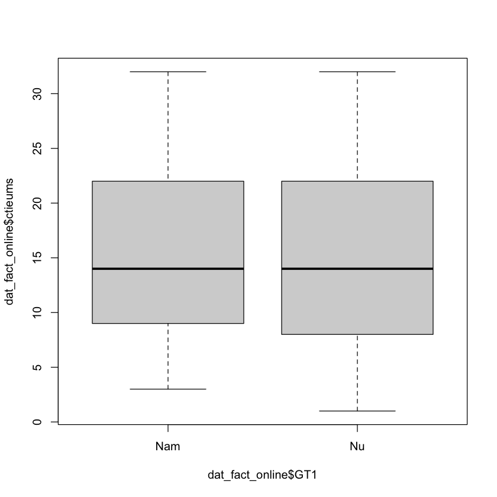

```r
# boxplot
par(bg='white')
boxplot(dat_fact_online$ctieums ~ dat_fact_online$GT1)
```

## Hypothesis testing

### Bivariate (association)

#### chi-square test

```r
# Crosstabs
table <- table(dat_fact_online$Hoc_van, dat_fact_online$Thu_nhap)

# Chi-square test
chisq_test <- chisq.test(table, simulate.p.value = TRUE)

# Phi and Cramer's V
phi <- sqrt(chisq_test$statistic / sum(table))
cramers_v <- sqrt(chisq_test$statistic / (sum(table) * (min(dim(table)) - 1)))

# Display results
cat('Table:')
print(table)
print(chisq_test, digits = 10)
cat('phi =', phi,'\n')
cat('cramers_v =', cramers_v)
```

```
Table:
                      duoi 10 10-14 15 tro len
  pho thong trung hoc      29    42         31
  cao dang-dai hoc         11    55         73
  tren dai hoc              0    10          6

	Pearson's Chi-squared test with simulated p-value (based on 2000
	replicates)

data:  table
X-squared = 27.229364, df = NA, p-value = 0.0004997501

phi = 0.326
cramers_v = 0.23
```

```r
# Gamma
gamma_result <- GoodmanKruskalGamma(dat_fact_online$Hoc_van, dat_fact_online$Thu_nhap)
cat('gamma:', gamma_result)
```

```
gamma: 0.386
```

```r
# Kendall's tau
kendall_result <- cor(dat_online$Hoc_van, dat_online$Thu_nhap, method = "kendall")
cat('\nkendall:', kendall_result)
```

```
kendall: 0.232
```

#### t-test

```r
# t-test
t_test <- t.test(dat_online$ctieums ~ dat_online$GT1)
print.listof(t_test)
```

```
statistic :
    t
0.122

parameter :
  df
53.1

p.value :
[1] 0.903

conf.int :
[1] -0.303  0.342
attr(,"conf.level")
[1] 0.95

estimate :
mean in group 1 mean in group 2
           1.71            1.69

null.value :
difference in means between group 1 and group 2
                                              0

stderr :
[1] 0.161

alternative :
[1] "two.sided"

method :
[1] "Welch Two Sample t-test"

data.name :
[1] "dat_online$ctieums by dat_online$GT1"
```

```r
pearson_test <- cor.test(dat_online$ctieums, dat_online$X1, method = "pearson")
print.listof(pearson_test)
```

```
statistic :
   t
1.11

parameter :
 df
255

p.value :
[1] 0.267

estimate :
   cor
0.0696

null.value :
correlation
          0

alternative :
[1] "two.sided"

method :
[1] "Pearson's product-moment correlation"

data.name :
[1] "dat_online$ctieums and dat_online$X1"

conf.int :
[1] -0.0533  0.1903
attr(,"conf.level")
[1] 0.95
```

#### anova

```r
# One-way ANOVA
anova_result <- aov(ctieums ~ Hoc_van, data = dat_online)

# Summary of the ANOVA
summary(anova_result)
```

```
             Df Sum Sq Mean Sq F value Pr(>F)
Hoc_van       1    2.3   2.281    2.48   0.12
Residuals   255  235.0   0.921
```

```r
# Welch's ANOVA
welch_anova <- oneway.test(ctieums ~ Hoc_van, data = dat_online, var.equal = FALSE)

# Display results
print(welch_anova)
```

```
	One-way analysis of means (not assuming equal variances)

data:  ctieums and Hoc_van
F = 2, num df = 2, denom df = 43, p-value = 0.2
```

## Factor analysis

### Cronbach Alpha

Cronbach's Alpha is a measure of internal consistency, which assesses how closely related a set of items are as a group. It is commonly used to evaluate the reliability of a scale or questionnaire. A higher Cronbach's Alpha value (typically above 0.7) indicates better reliability. In the next step, we will calculate Cronbach's Alpha for selected variables in our dataset.

```r
# cronbach alpha: to evaluate variable
items <- dat_online[, c("TT1", "TT2", "TT3")]
labels <- var_label(dat_online)
alpha_results <- alpha(items)
kable(alpha_results$total,booktabs=T)
```

```
|   | raw_alpha| std.alpha| G6(smc)| average_r|  S/N|  ase| mean|    sd| median_r|
|:--|---------:|---------:|-------:|---------:|----:|----:|----:|-----:|--------:|
|   |     0.908|     0.908|   0.877|     0.767| 9.89| 0.01|  4.4| 0.486|    0.737|
```

The reliability of the scale is high, with a Cronbach's Alpha of 0.908, indicating strong internal consistency. The average item correlation is 0.767, reflecting strong relationships among the items. Additionally, the measurement quality is reliable, with a signal-to-noise ratio (S/N) of 9.89.

To evaluate the impact of individual items on the reliability of the scale, the following code is used:

```r
alpha_drop <- as.data.frame(alpha_results$alpha.drop)
row.names(alpha_drop) <- labels[names(items)]
print(alpha_drop$raw_alpha)
```

```
[1] 0.917 0.836 0.848
```

So it imply that we can group TT1, TT2, TT3 into 1 group. Next, we will example if we can group TT1, HH1 and DV1 into 1 group

```r
# cronbach alpha: to evaluate variable
items <- dat_online[, c("TT1", "HH1", "DV1")]
labels <- var_label(dat_online)
alpha_results <- alpha(items)

print('Total:')
kable(alpha_results$total,booktabs=T)
print('Drop:')
kable(alpha_results$alpha.drop)
```

```
[1] "Total:"
```

```
|   | raw_alpha| std.alpha| G6(smc)| average_r|   S/N|  ase| mean|    sd| median_r|
|:--|---------:|---------:|-------:|---------:|-----:|----:|----:|-----:|--------:|
|   |     0.276|     0.333|   0.299|     0.143| 0.499| 0.08| 3.98| 0.409|    0.059|
```

```
[1] "Drop:"
```

```
|    | raw_alpha| std.alpha| G6(smc)| average_r|    S/N| alpha se| var.r|  med.r|
|:---|---------:|---------:|-------:|---------:|------:|--------:|-----:|------:|
|TT1 |     0.107|     0.111|   0.059|     0.059|  0.125|    0.107|    NA|  0.059|
|HH1 |     0.547|     0.550|   0.379|     0.379|  1.220|    0.056|    NA|  0.379|
|DV1 |    -0.018|    -0.019|  -0.010|    -0.010| -0.019|    0.117|    NA| -0.010|
```

No, the raw_alpha is so low, we better keep 3 column separate instead of grouping them

### PCA

```r
library(psych)
library(knitr)
library(kableExtra)

# Select relevant columns
items <- dat_online[, c("TT1", "TT2", "TT3", "HH1", "HH2", "HH3", "DV1", "DV2", "DV3", "DV4", "DV5")]

# Get variable labels if available
labels <- var_label(dat_online)[names(items)]
if(all(is.na(labels))) labels <- names(items)

# Determine factors (eigenvalues > 1)
pca_scree <- principal(items, nfactors = ncol(items), rotate = "none")
num_factors <- sum(pca_scree$values > 1)

# Run PCA with varimax rotation
pca_rotated <- principal(items, nfactors = num_factors, rotate = "varimax")
rotated_loadings <- as.data.frame(unclass(pca_rotated$loadings))
row.names(rotated_loadings) <- labels

# Create matrix with only primary factors
rotated_matrix_primary <- rotated_loadings
rotated_matrix_primary[] <- ""
for(i in 1:nrow(rotated_loadings)) {
  max_col <- which.max(abs(as.numeric(rotated_loadings[i,])))
  rotated_matrix_primary[i, max_col] <- round(as.numeric(rotated_loadings[i, max_col]), 3)
}

# Print the rotated component matrix
kable(rotated_matrix_primary, format = 'pandoc')
```

```
                                                                      RC1     RC3     RC2
--------------------------------------------------------------------  ------  ------  ------
mua hang truc tuyen hoat dong 24h nen co the mua vao bat cu luc nao           0.859
mua hang truc tuyen giup tiet kiem thoi gian                                  0.921
cach thuc mua va thanh toan de dang                                           0.92
san pham phu hop voi so tien ma toi tra                                               0.895
san pham phong phu                                                                    0.816
san pham dam bao chat luong nhu thong tin cung cap tren web                           0.952
nhan vien vui ve giai dap thac mac cua khach hang                     0.805
nhan vien luon ho tro khi khach hang can                              0.83
nhan vien luon giup do khach hang tan tinh                            0.755
khi mua sam online hang hoa duoc giao tan noi                         0.752
hang hoa duoc giao dung thoi han                                      0.776
```

These factors provide a clear structure for understanding customer perceptions and can guide targeted improvements in online shopping experiences.

In the earlier PCA, we use 3 factors. But how we can find out 3 is the best number? We can plot a scree chart, it show the eigenvalues of the factors in descending order. The "elbow" point in the scree plot indicates the optimal number of factors to retain, as it represents the point where the eigenvalues start to level off. Then we choose 1 for threshold as a rule of thumb

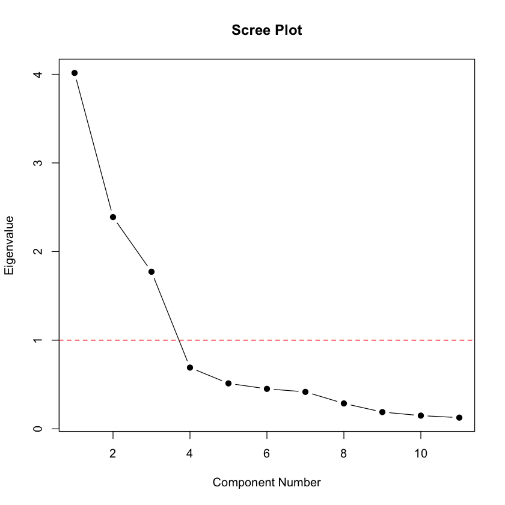

```r
scree_plot <- function(data) {
  # Run PCA
  pca_results <- prcomp(data, scale. = TRUE)

  # Extract eigenvalues
  eigenvalues <- pca_results$sdev^2

  # Calculate variance explained
  var_explained <- eigenvalues / sum(eigenvalues) * 100

  # Create data frame for plotting
  plot_data <- data.frame(
    Component = 1:length(eigenvalues),
    Eigenvalue = eigenvalues,
    Variance = var_explained
  )

  # Plot scree plot
  plot(plot_data$Component, plot_data$Eigenvalue,
       type = "b", pch = 19,
       xlab = "Component Number",
       ylab = "Eigenvalue",
       main = "Scree Plot")

  # Add horizontal line at eigenvalue = 1
  abline(h = 1, lty = 2, col = "red")
}

# Usage
par(bg='white')
items <- dat_online[, c("TT1", "TT2", "TT3", "HH1", "HH2", "HH3", "DV1", "DV2", "DV3", "DV4", "DV5")]
scree_plot(items)
```

## Regression

```r
# Load the dataset
dat_reg <- read_sav("/Users/macbook/Library/CloudStorage/GoogleDrive-tranquangthanhcong@gmail.com/My Drive/study/ueh master/multivariate/data/HOIQUIBOI.sav")
head(dat_online,2)
```

A tibble: 2 x 26

| TT1 <dbl+lbl> | TT2 <dbl+lbl> | TT3 <dbl+lbl> | HH1 <dbl+lbl> | HH2 <dbl+lbl> | HH3 <dbl+lbl> | DV1 <dbl+lbl> | DV2 <dbl+lbl> | DV3 <dbl+lbl> | DV4 <dbl+lbl> | ... | Nghe <dbl+lbl> | Thu_nhap <dbl+lbl> | Hoc_van <dbl+lbl> | ctieums <dbl> | X1 <dbl> | X3 <dbl> | Y <dbl> | X2 <dbl> | CD_DH <dbl+lbl> | chitieuMH <dbl+lbl> |
| --- | --- | --- | --- | --- | --- | --- | --- | --- | --- | --- | --- | --- | --- | --- | --- | --- | --- | --- | --- | --- |
| 5 | 5 | 5 | 2 | 4 | 4 | 5 | 5 | 5 | 5 | ... | 1 | 3 | 2 | 0.5 | 5.0 | 3.33 | 4.92 | 5 | 1 | 1 |
| 4 | 4 | 4 | 4 | 4 | 4 | 3 | 3 | 3 | 4 | ... | 1 | 2 | 2 | 1.0 | 3.4 | 4.00 | 3.80 | 4 | 1 | 2 |

```r
# convert value to factors (readable)
dat_fact_reg <- as_label(dat_reg) %>% as_factor()
head(dat_fact_reg,2)
```

A tibble: 2 x 3

| sluong <fct> | dgia <fct> | cphiqc <fct> |
| --- | --- | --- |
| 350 | 5.5 | 3.3 |
| 460 | 7.5 | 3.3 |

### Scatter plot

We can have a look on how the relationship variables is by plot a scatter chart. We can use a simple builtin function in R

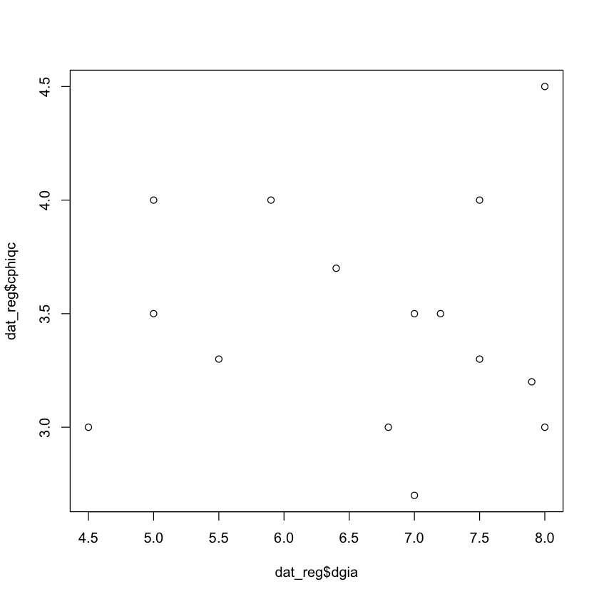

```r
par(bg = 'white')
plot(dat_reg$dgia, dat_reg$cphiqc)
```

or we can use ggplot2 which more options to adjust

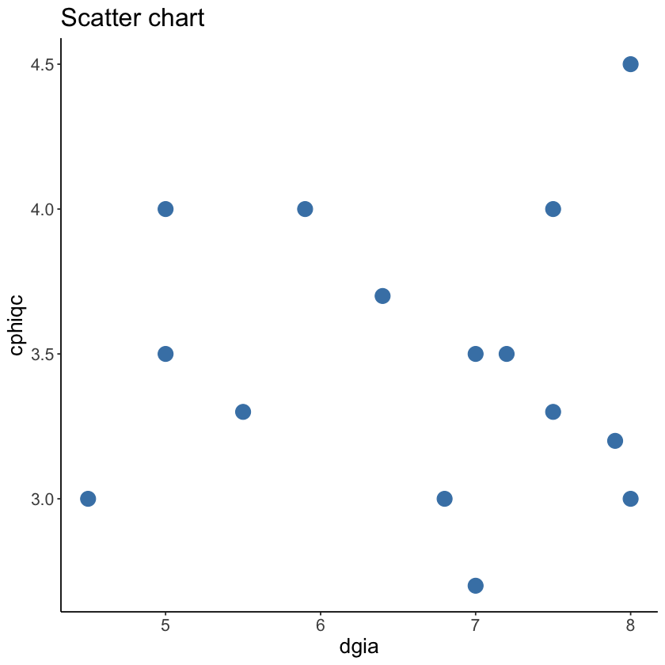

```r
# plot scatter chart of dat_hoiquy for dgia and cphiquangcao
dat_reg %>%
  ggplot(aes(x = dgia, y = cphiqc)) +
  geom_point(size = 5, color = "steelblue") +
  labs(title = "Scatter chart")
```

### Linear model

```r
# run linear regression with dependient is sluong and others is independent
model <- lm(sluong ~ dgia + cphiqc, data = dat_reg)
anova(model) %>% kable(format='pandoc')
summary(model)
stargazer(model, type = "text", digits = 4)
```

```
             Df   Sum Sq   Mean Sq   F value   Pr(>F)
----------  ---  -------  --------  --------  -------
dgia          1    11100     11100      4.93    0.046
cphiqc        1    18360     18360      8.15    0.014
Residuals    12    27033      2253        NA       NA
```

```
Call:
lm(formula = sluong ~ dgia + cphiqc, data = dat_reg)

Residuals:
   Min     1Q Median     3Q    Max
-63.80 -33.80  -9.09  17.18  96.15

Coefficients:
            Estimate Std. Error t value Pr(>|t|)
(Intercept)    306.5      114.3    2.68    0.020 *
dgia           -25.0       10.8   -2.31    0.040 *
cphiqc          74.1       26.0    2.85    0.014 *
---
Signif. codes:  0 '***' 0.001 '**' 0.01 '*' 0.05 '.' 0.1 ' ' 1

Residual standard error: 47.5 on 12 degrees of freedom
Multiple R-squared:  0.521,	Adjusted R-squared:  0.442
F-statistic: 6.54 on 2 and 12 DF,  p-value: 0.012
```

```
===============================================
                        Dependent variable:
                    ---------------------------
                              sluong
-----------------------------------------------
dgia                        -25.0000**
                             (10.8000)

cphiqc                       74.1000**
                             (26.0000)

Constant                    307.0000**
                            (114.0000)

-----------------------------------------------
Observations                    15
R2                            0.5210
Adjusted R2                   0.4420
Residual Std. Error      47.5000 (df = 12)
F Statistic            6.5400** (df = 2; 12)
===============================================
Note:               *p<0.1; **p<0.05; ***p<0.01
```

```r
# view model dubin watson
library(lmtest)
options(digits=10)
dwtest(model)
```

```
	Durbin-Watson test

data:  model
DW = 1.6831203, p-value = 0.3018732
alternative hypothesis: true autocorrelation is greater than 0
```

```r
dat_reg$resid<-model$residuals
dat_reg$pred<-model$fitted.values
```

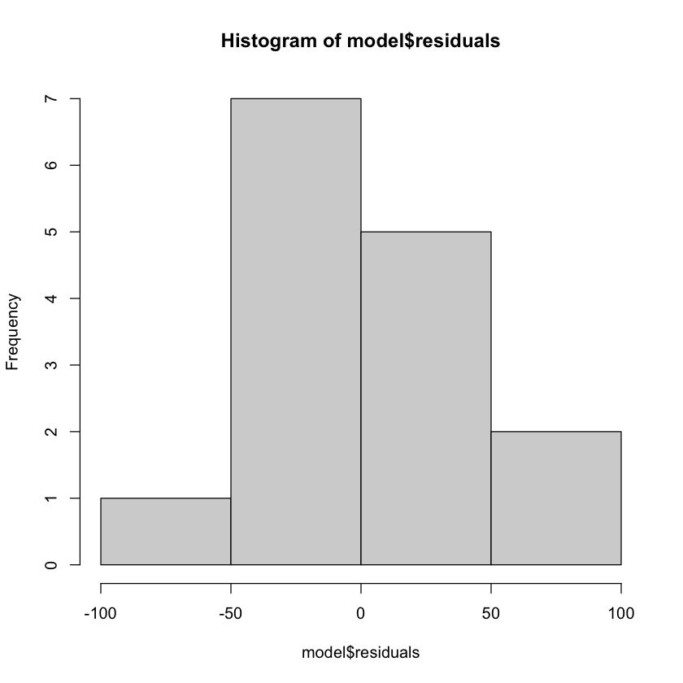

```r
hist(model$residuals)
```

#### normalization

```r
dat_reg$sluong_scale <- scale(dat_reg$sluong)
dat_reg$dgia_scale <- scale(dat_reg$dgia)
dat_reg$cphiqc_scale <- scale(dat_reg$cphiqc)
model <- lm(sluong_scale ~ dgia_scale + cphiqc_scale, data = dat_reg)
anova(model)
summary(model)
stargazer(model, type = "text", digits = 4)
```

A anova: 3 x 5

|  | Df <int> | Sum Sq <dbl> | Mean Sq <dbl> | F value <dbl> | Pr(>F) <dbl> |
| --- | --- | --- | --- | --- | --- |
| dgia_scale | 1 | 2.750875603 | 2.7508756035 | 4.927449645 | 0.04645635254 |
| cphiqc_scale | 1 | 4.549815501 | 4.5498155009 | 8.149763933 | 0.01449362680 |
| Residuals | 12 | 6.699308896 | 0.5582757413 | NA | NA |

```
Call:
lm(formula = sluong_scale ~ dgia_scale + cphiqc_scale, data = dat_reg)

Residuals:
       Min         1Q     Median         3Q        Max
-1.0042793 -0.5320155 -0.1430723  0.2703761  1.5136884

Coefficients:
                  Estimate    Std. Error  t value Pr(>|t|)
(Intercept)   3.905180e-16  1.929207e-01  0.00000 1.000000
dgia_scale   -4.606330e-01  1.997844e-01 -2.30565 0.039788 *
cphiqc_scale  5.703404e-01  1.997844e-01  2.85478 0.014494 *
---
Signif. codes:  0 '***' 0.001 '**' 0.01 '*' 0.05 '.' 0.1 ' ' 1

Residual standard error: 0.7471785 on 12 degrees of freedom
Multiple R-squared:  0.5214779,	Adjusted R-squared:  0.4417243
F-statistic: 6.538607 on 2 and 12 DF,  p-value: 0.01200637
```

```
===============================================
                        Dependent variable:
                    ---------------------------
                           sluong_scale
-----------------------------------------------
dgia_scale                   -0.4606**
                             (0.1998)

cphiqc_scale                 0.5703**
                             (0.1998)

Constant                      0.0000
                             (0.1929)

-----------------------------------------------
Observations                    15
R2                            0.5215
Adjusted R2                   0.4417
Residual Std. Error      0.7472 (df = 12)
F Statistic            6.5386** (df = 2; 12)
===============================================
Note:               *p<0.1; **p<0.05; ***p<0.01
```

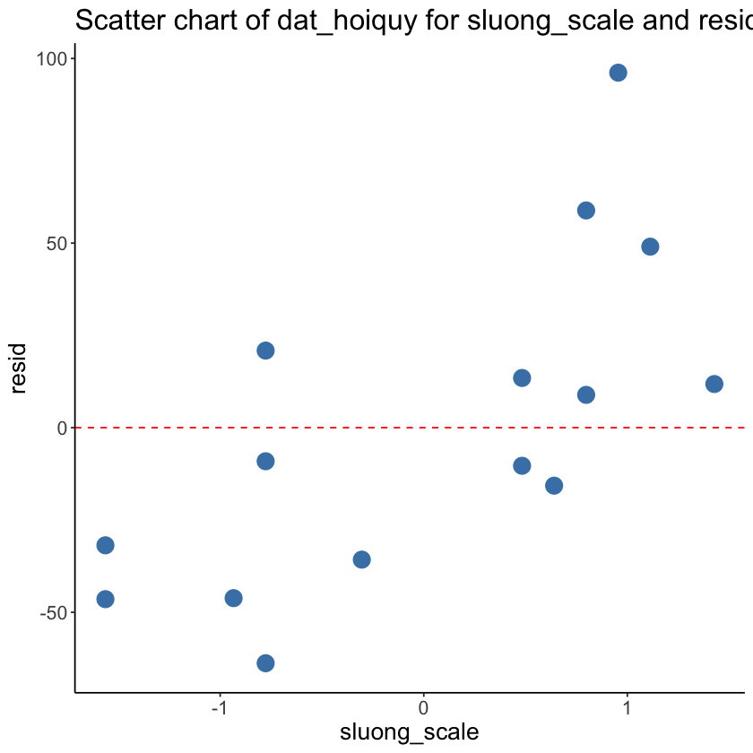

```r
dat_reg %>%
  ggplot(aes(x = sluong_scale, y = resid)) +
  geom_point(size=5,color='steelblue') +
  geom_hline(yintercept = mean(model$residuals), linetype="dashed", color = "red") +
  labs(title = "Scatter chart of dat_hoiquy for sluong_scale and residuals")
```